# SPC - Data Analysis - Lung Cancer Germany - Publication ‘Incidence of Smoking-related Second Primary Cancers after Lung Cancer in Germany’

SIR other (IARC def. - 18)

1.07

1.03–1.12

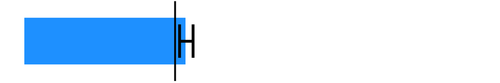

0.96

0.91–1.02

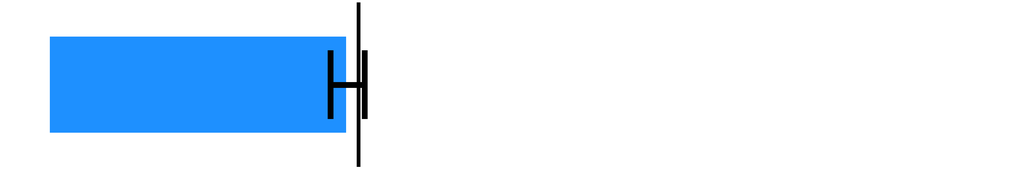

1.36

1.26–1.46

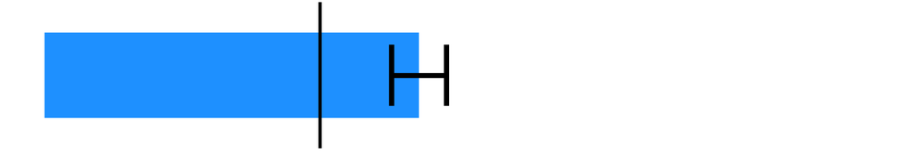

SIR other (Boakye def. - 7)

1.14

1.10–1.19

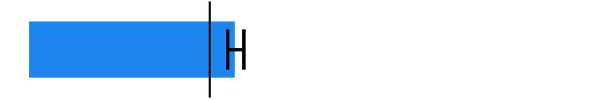

1.04

0.99–1.09

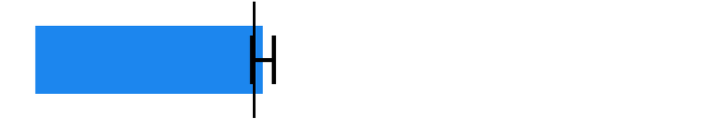

1.39

1.30–1.48

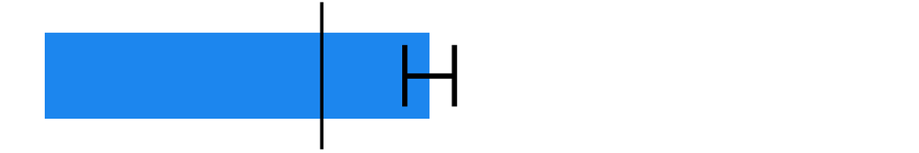

SIR other (Barclay def. - 6)

1.17

1.14–1.21

[figure not shown]

1.08

1.04–1.13

[figure not shown]

1.43

1.35–1.51

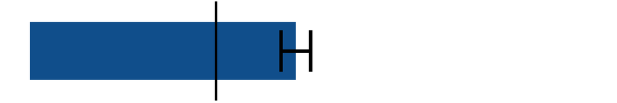

Smo-R: Ratio SIR vs. SIR other

Smo-R (IARC def. - 18)

1.39

1.31–1.46

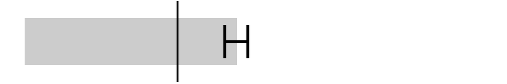

1.46

1.37–1.56

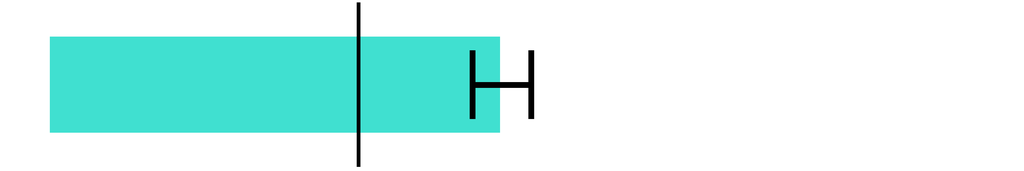

1.33

1.20–1.47

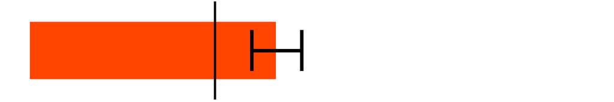

Smo-R (Boakye def. - 7)

1.28

1.21–1.35

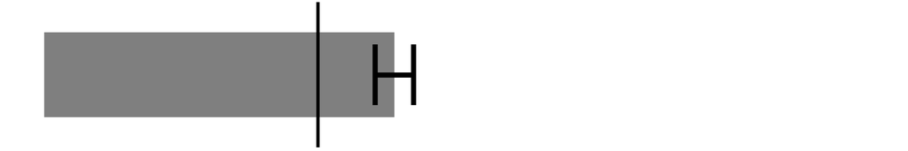

1.32

1.23–1.41

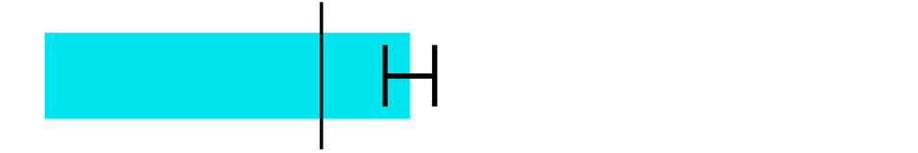

1.33

1.20–1.48

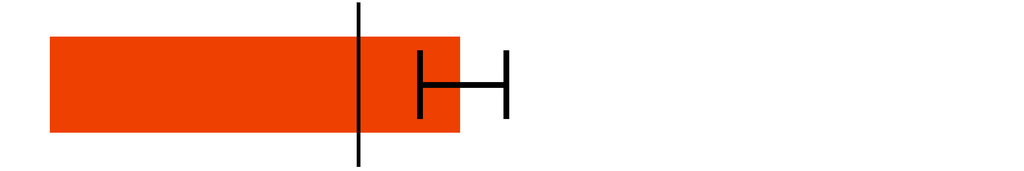

Smo-R (Barclay def. - 6)

1.42

1.34–1.51

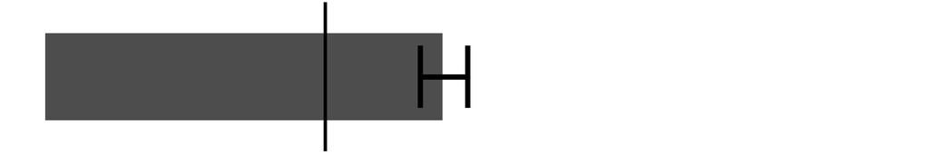

1.44

1.34–1.54

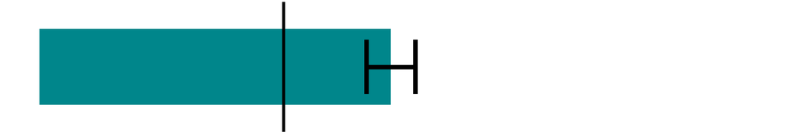

1.71

1.50–1.95

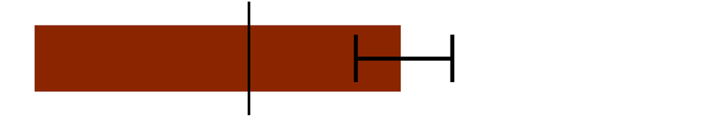